# EST613 - ESTATÍSTICA BAYESIANA LISTA DE EXERCÍCIOS 01

Author

João Paulo Gusmão Teixeira (64316)

1. Considere uma partição do espaço amostral e um evento tal que . Enuncie o Teorema de Bayes:
   $$P(A_k|B) = \frac{P(B|A_k)P(A_k)}{\sum_\limits{i=1}^{n} P(B|A_i) P(A_i) }, i = 1, ..., k, ..., n$$
   Identifique e explique o papel de:
1. $P(A_k)$
2. $P(B|A_k)$
3. $\sum_\limits{i=1}^{n} P(B|A_i) P(A_i)$
4. $P(A_k|B)$

## Resposta 01

1. $P(A_k)$ representa a probabilidade a priori, ou seja, a probabilidade de ocorrência do evento $A_k$ sem se ter o conhecimento do evento $B$
2. $P(B|A_k)$ representa a probabilidade condicional , ou seja, a contribuição da ocorrência do evento $A_k$ para a ocorrência do evento $B$. Pode ser chamada também de função de verossimilhança.
3. $\sum_\limits{i=1}^{n} P(B|A_i) P(A_i)$ indica que é usada todas as probabilidades a priori para calcular a probabilidade total de ocorrência do evento $B$ no espaço amostral. Nesse sentido, cada termo calcula a probabilidade da interseção $P(B \cap A)$, ou seja, a chance de se estar no cenário $A_i$ e o evendo $B$ acontecer nele. Por fim, pode-se entender que existe um efeito normalizador.
4. $P(A_k|B)$ representa a contribuição da ocorrência do evento $B$ para a ocorrência do evento $A_k$. Pode ser chamado também de probailidade a posteriori, que é atualizada após receber informação sobre a ocorrência do evento $B$.
2. Considere um teste utilizado para auxiliar no diagnóstico de diabetes em determinada população. Sabe-se que:
- **6%** dos indivíduos dessa população têm diabetes;
- entre os indivíduos que têm diabetes, o teste apresenta resultado positivo em 90% dos casos (**sensibilidade**);
- entre os indivíduos que não têm diabetes, o teste apresenta resultado positivo em **5%** dos casos (**taxa de falsos positivos**).

Considere os eventos:

$D =$ {*o indivíduo tem diabetes*}

$\hat{D} =$ {*o indivíduos **não** tem diabetes*}

$T^+ =$ {*o teste apresenta resultado **positivo***}

$T^- =$ {*o teste apresenta resultado **negativo***}

1. Determine a probabilidade de o teste apresentar **resultado negativo, dado que o indivíduo tem diabetes**, isto é, $P(T^-|D)$.
2. Sabendo que um indivíduo apresentou **resultado negativo no teste**, determine a probabilidade de que ele **tenha diabetes**, isto é, $P(D|T^-)$.
3. Compare as probabilidades $P(D)$ e $P(D|T^-)$ e interprete, no contexto do problema, **como a observação de um resultado negativo modifica a probabilidade inicialmente atribuída à ocorrência de diabetes**.

## Resposta 02

Primeiramente, armazenaremos as informações do problema.

```r
prevDiab <- 0.06  # 6% da população têm diabetes P(D)

sensib <- 0.9  # entre os que tem diabetes, o resultado consegue detectar em 90% das vezes P(T+ | D)
falsonegativo <- 1 - sensib  # o teste não detecta a doença em 10% das vezes P(T-|D)

falsopositivo <- 0.05  # o teste detecta a doença em quem não tem em 5% das vezes. P(T+|\hat{D})
especi <- 1 - falsopositivo  # o teste dá negativo para uma pessoa saudável em 95% das vezes P(T- | \hat{D})
```

Agora podemos proceder aos cálculos solicitados

### Resposta 02.a) $P(T^-|D)$

```r
# a. P(T^-|D) P(T^- |D) = 1 - P(T+ |D)

# Já calculado no chunck Resposta 2, sendo esse o falso negativo.

cat("\n# P(T^-|D) = ", falsonegativo, sep = "")

# P(T^-|D) = 0.1
```

Portanto, a probabilidade é $P(T^-|D) =$ 0.1.

### Resposta 02.b) $P(D|T^-)$

```r
# P(D|T-) = P(T-|D)P(D) / P(T-)

# Precisaremos calcular a possibilidade P(T-)

# P(T-) = P(T-|D)P(D) + P(T-|\hat{D})P(\hat{D})

prob_Nterdiab = falsopositivo * prevDiab + especi * (1 - prevDiab)

cat("Probabilidade de não ter a doença: ", "P(T-) = ", prob_Nterdiab, sep = "")
Probabilidade de não ter a doença: P(T-) = 0.896

# Agora, podemos calcular o solicitado

prob2b <- (falsonegativo * prevDiab)/(prob_Nterdiab)
cat("Prob ter diabetes sendo que o resultado deu negativo: ", prob2b, sep = "")
Prob ter diabetes sendo que o resultado deu negativo: 0.006696429
```

Dado que o indivíduos fez o teste e esse deu negativo, há uma probabilidade de 0.0067 de ele ter a doença.

### Resposta 2c

A prevalência da diabetes na população estudada é de 6%. Antes da realização de um teste, é como se um indivíduos tivesse 6% de chance de apresentar diabetes. Após a realização de um teste, o qual possui 90% de eficácia (sensibilidade), a nova probabilidade de um indivíduo ter a doença reduz substancialmente para 0.67%. Isso mostra que o conhecimento a respeito de algo pode influenciar nas probabilidades de calculamos.

3. Em uma determinada cidade, os eleitores foram classificados em três grupos etários:
- **20%** são jovens, com idade entre 18 e 30 anos;
- **50%** são adultos, com idade entre 31 e 50 anos;
- **30%** são idoso, com 51 anos ou mais.

Uma pesquisa eleitoral indicou que:

- **60% dos jovens** apoiam determinado candidato;
- **40% dos adultos** apoiam esse candidato;
- **20% dos idosos** apoiam esse candidato.

Considere os eventos:

$J = $ *{o eleitor é **jovem**}*

$A = $ *{o eleitor é **adulto**}*

$I = $ *{o eleitor é **idoso**}*

$C = $ *{o eleitor apoia o candidato}*

Com base nas informações, determine:

**a)** A Probabilidade de um eleitor escolhido aleatoriamente **apoias o candidato.**

**b)** Sabendo que um eleitor **apoia o candidato**, determine a probabilidade de que ele seja **jovem**.

**c)** Sabendo que um eleitor **não apoia o candidato**, determine a probabilidade de que ele seja **idoso**.

**d)** Compare $P(J)$ com $P(J|C)$ e $P(I)$ com $P(I|\hat{C})$. Interprete como a informação sobre o apoio, ou não, ao candidato modifica as probabilidades inicialmente atribuídas aos grupos etários.

## Resposta 03

Tal qual no exercício anterior, armazenaremos as informações do problema.

```r
propjovem = 0.2  # Proporção de jovens na cidade
propadulto = 0.5  # Proporção de adultos na cidade
propidoso = 0.3  # Proporção de idoso na cidade

apoiojovem = 0.6  # Apoio de jovens ao candidato X
apoioadulto = 0.4  # '' '' adultos '' ''
apoioidoso = 0.2  #  '' '' idosos  '' ''
```

### Resposta 03a

```r
# Prob eleitor escolhido aleatoriamente apoiar o candidato

# P(C) = P(C|J)*P(J) + P(C|A)*P(A) + P(C|I)*P(I)

prob_apoiar <- (apoiojovem * propjovem) + (apoioadulto * propadulto) + (apoioidoso *
    propidoso)
```

A probabilidade de um eleitor selecionado ao acaso apoiar o candidato é de 38% (P(C) = 0.38).

### Resposta 03b

```r
# Sei que um eleitor apoia o candidato -> chance de ser jovem

# P(J|C) = P(C|J)P(J) /P(C)

prob_serjovem <- (apoiojovem * propjovem)/prob_apoiar

cat("P(J|C) =", round(prob_serjovem, 4))
P(J|C) = 0.3158
```

Sabendo que o eleitor apoia o candidato, a probabilidade de ele ser jovem é de aproximadamente 31.58% ($P(J|C) \approx$ 0.3158).

### Resposta 3c

```r
# Sei que um eleitor não apoia o candidato -> chance de ser idoso Estou usando
# o ! tal qual na programação, mas em aula vimos como \hat(C) P(I|!C) =
# P(!C|I)P(I) /P(!C)

# P(!C) = 1 - P(C)
prob_naoapoiar <- 1 - prob_apoiar

# P(!C|I) = 1 - P(C|I)
prob_nao_apoio_idoso <- 1 - apoioidoso

# P(I|!C) = P(!C|I) * P(I) / P(!C)
prob_seridoso <- (prob_nao_apoio_idoso * propidoso)/prob_naoapoiar

cat("P(J|!C) =", round(prob_seridoso, 4))
P(J|!C) = 0.3871
```

Sabendo que o eleitor não apoia o candidato, a probabilidade de ele ser idoso é de aproximadamente 38.71% ($P(J|C) \approx$ 0.3871).

### Resposta 3d

De início, imaginamos que a chance de alguém ser idoso, jovem ou adulto se dá exclusivamente pela proporção da população que está em cada um desses estratos. Todavia, ao descobrir uma nova informação, seja de que o eleitor apoia um candidato ou que não apoia, esse conhecimento permite alterar as probabilidades além daquelas relativas tão somente à proporção. Isso é pode ser percebido ao analisar dois cenários:

1. P(J) = 20% (proporção da população), mas sabendo que um eleitor apoia o candidato, a probabilidade de ser jovem passa para P(J|C) = 31.58%
2. P(I) = 30% (proporção da população), mas sabendo que um eleitor não apoia o candidato, a probabilidade de ser idoso passa para P(I/!C) = 38.71%.
4. Uma empresa de alimentos processa frutos provenientes de duas fazendas distintas. A Fazenda A é responsável por 40% dos frutos processados, enquanto a Fazenda B contribui com os 60% restantes.

Dados históricos indicam que:

- 6% dos frutos provenientes da Fazenda A estão maduros e prontos para consumo;
- 8% dos frutos provenientes da Fazenda B estão maduros e prontos para consumo.

Considere os eventos:

$$A = {\textit{o fruto é proveniente da Fazenda A}}$$

$$B = {\textit{o fruto é proveniente da Fazenda B}}$$

$$M_i = {\textit{o i − ésimo fruto selecionado está maduro e pronto para consumo}}$$

Responda:

1. Determine a probabilidade de um fruto selecionado aleatoriamente **não estar maduro e pronto para consumo**.
2. Sabendo que o primeiro fruto selecionado está **maduro e pronto para consumo**, determine a probabilidade de que ele seja proveniente da **Fazenda A**.
3. Considere agora que dois frutos são selecionados de um mesmo lote, cuja fazenda de origem é desconhecida. Suponha que, condicionada à fazenda de origem, a condição de maturação dos frutos possa ser considerada independente.

Sabendo que o **primeiro fruto selecionado está maduro** e o **segundo fruto não está maduro**, determine

$$P(A|M_1 \cap \bar{M}_2)$$

Considere as duas formas de atualização apresentadas a seguir.

**i. Atualização conjunta das duas informações**

$$P(A|M_1 \cap \bar{M}_2) = \frac{P(M_1 ∩ \bar{M}_2|A)P(A)}{ P(M_1 \cap \bar{M}_2|A)P(A) + P(M_1 \cap \bar{M}_2|B)P(B)}$$

e, utilizando a independência condicional,

$$P(A|M_1 \cap \bar{M}_2) = \frac{P(M_1|A)P(\bar{M}_2|A)P(A)}{P(M_1|A)P(\bar{M}_2|A)P(A) + P(M_1|B)P(\bar{M}_2|B)P(B)}$$

**ii. Atualização sequencial das informações**

Primeiramente, considere a informação e, em seguida, incorpore a informação:

$$P(A|M_1 \cap \bar{M}_2) = \frac{P(A|M_1)P(\bar{M}_2|A)}{P(A|M_1)P(\bar{M}_2|A) + P(B|M_1)P(\bar{M}_2|B)}$$

Calcule e justifique por que as abordagens i e ii conduzem ao mesmo resultado e interprete essa equivalência no contexto do Teorema de Bayes como uma regra de atualização sequencial da informação. Não é necessário demonstrar algebricamente a equivalência.

4. Sob o mesmo contexto do item anterior, suponha agora que o **primeiro fruto selecionado não esteja maduro** e o **segundo esteja maduro e pronto para consumo**. Determine a probabilidade de que os frutos sejam provenientes da **Fazenda A**, isto é,

$$P(A|\bar{M}_1 \cap M_2)$$

Compare essa probabilidade com

$$P(A|M_1 \cap \hat{M}_2)$$

obtida no item c. As duas probabilidades são iguais? **Justifique o resultado**.

## Resposta 04

Como boa prática, vamos armazenar as informações que temos para posterior utilização.

```r
# Dados das fazendas

# fruto veio de qual fazenda?
A <- naoB <- 0.4
B <- naoA <- 0.6

# dados históricos de qualidade Mi - fruto i estar maduro ou nao
MA <- 0.06
naoMA <- 1 - MA
MB <- 0.08
naoMB <- 1 - MB
```

Agora, vamos às letras.

### Resposta 4a

```r
# Prob fruto aleatorio não estar maduro

# P(!Mi) = P(!MI|A)*P(A) + P(!M|B)*P(B)

naoMi <- (naoMA * A) + (naoMB * B)

cat(naoMi)
0.928
```

### Resposta 4b

```r
# Sei que o primeiro fruto está maduro - veio de A?

# P(A|Mi) = P(Mi|A)*P(A) / P(Mi)

Mi <- 1 - naoMi

A_dado_Mi <- (MA * A)/Mi

cat("P(não M) =", A_dado_Mi)
P(não M) = 0.3333333
```

Sabendo que o primeiro fruto está maduro, a probabilidade de ter vindo da Fazenda A é de aproximadamente 33.33% [$P(A|M_1) = \frac{1}{3} \approx$ 0.3333].

### Resposta 4c

#### Abordagem 01: atualização conjunta

```r
# --- Abordagem 1: atualização conjunta ---

# Por independência condicional: P(A|M1 inters naoM2) = P(M1|A) * P(naoM2|A) *
# P(A) / [ P(M1|A)P(naoM2|A)*P(A) + P(M1|B)*P(naoM2|B)*P(B)]

numerador_4c1 <- MA * naoMA * A
denominador_4c1 <- numerador_4c1 + MB * naoMB * B

AM1naoM2_conjunta <- numerador_4c1/denominador_4c1

cat("i.   P(A | M1, naoM2)   =", round(AM1naoM2_conjunta, 4), "\n")
i.   P(A | M1, naoM2)   = 0.3381
```

#### Abordagem 02: atualização sequencial

```r
#--- Abordagem 2: atualização sequencial ---

# P(A|M1 inter naoM2) = P(A|M1)P(naoM2|A) / P(A|M1)P(naoM2|A) +
# P(B|M1)P(naoM2|B)

B_dado_Mi = 1 - A_dado_Mi

AM1naoM2_sequencial <- A_dado_Mi * naoMA/(A_dado_Mi * naoMA + B_dado_Mi * naoMB)



cat("ii.  P(A | M1, não M2) [Sequencial] =", round(AM1naoM2_sequencial, 4), "\n")
ii.  P(A | M1, não M2) [Sequencial] = 0.3381
```

Ambas as abordagens resultam em uma $P(A \mid M_1, \hat{M}_2) \approx$ 33.81$%$, pois o Teorema de Bayes possui a propriedade de invariância à ordem de agregação dos dados sob independência condicional.

Na atualização sequencial, a distribuição a posteriori obtida após a primeira observação ($M_1$) torna-se a distribuição a priori da observação seguinte ($\hat{M}_2$).Isso evidencia o aprendizado bayesiano, seja ele feito ao calcular em conjunto ou em sequência.

### Respsota 4d

```r
# P(A | M1 inter M2) = P(A|naoM1) * P(M2|A) / [P(A|naoM1) * P(M2|A) +
# P(B|naoM1)*P(M2|B)

# P(A|naoM1) = P(naoM1|A)*P(A) / P(naoM1)
A_dado_naoM1 <- (naoMA * A)/naoMi

B_dado_naoM1 <- 1 - A_dado_naoM1

AnaoM1M2_sequencial <- A_dado_naoM1 * MA/(A_dado_naoM1 * MA + B_dado_naoM1 * MB)


cat("P(A | não M1, M2) =", round(AnaoM1M2_sequencial, 4))
P(A | não M1, M2) = 0.3381
```

**NoteComparação propabilidades**

Item 4c - $P(A|M_1 \cap \hat{M}_2)$ = 0.3381

Item 4d - $P(A|\hat{M}_1 \cap M_2)$ = 0.3381

As probabilidades $P(A|M_1 \cap \hat{M}_2) = P(A|\hat{M}_1 \cap M_2) = 0,3381$ são iguais, pois há independência da variável resposta, ou seja, os fritps são i.i.d (independentes e identicamente distribuídos). Então $P(M_1, \hat{M}_2 \mid A) = P(M_1 \mid A) \cdot P(\hat{M}_2 \mid A) = P(\hat{M}_1 \mid A) \cdot P(M_2 \mid A) = P(\hat{M}_1, M_2 \mid A)$. O Mesmo vale para a fazenda B.

5. Considere as seguintes variáveis aleatórias observadas em diferentes estudos:
- X = número de plantas que apresentam determinada doença em uma parcela com 50 plantas;
- Y = altura, em centímetros, de uma planta selecionada ao acaso;
- I = ocorrência ou não de germinação de uma semente selecionada ao acaso;
- Z = tempo, em dias, entre o plantio e a germinação de uma semente.
- W = número de insetos capturados em uma armadilha durante um período de 24 horas;

Para cada variável:

1. Classifique-a como discreta ou contínua e justifique sua resposta com base no conjunto de valores que ela pode assumir.
2. Explique como as probabilidades são atribuídas ou calculadas em cada caso, destacando a diferença entre uma função de probabilidade e uma função densidade de probabilidade.
3. Considere um valor específico pertencente ao suporte de uma variável discreta e um valor específico pertencente ao suporte de uma variável contínua. Compare

$$P(X = x) e P(Y = y)$$

e explique por que essas probabilidades apresentam comportamentos distintos.

4. Para uma variável contínua, explique como deve ser calculada a probabilidade de a variável assumir valores em um intervalo (a, b).

## Resposta 05

### Resposta 5a)

- X: discreta –> $x \in \{0, 1, 2, \dots, 50\}$
- Y: continua –> $y \in \{0 \le y \le +\infty\}$ ou $x \in [0, 50]$
- I: discreta –> $i \in \{0, 1\}$ ou $i \in \{\text{V}, \text{F}\}$
- Z: contínuo –> $z \in \{0, \le z \le +\infty \}$
- W: discreta –> $w \in \{0,1,2,3,...\}$

### Resposta 5b)

- **Variáveis Discretas ($X, I, W$):**  
  As probabilidades são atribuídas pontualmente por uma Função de Probabilidade (f.p), dada por $p(x) = P(X = x) = P(x) \quad \forall \: x$.

  Para tanto, precisa satisfazer as condições:
  $$p(x) \ge 0,\, \forall \: x \quad \text{e} \quad \sum_{x \in \mathcal{S}} p(x) = 1$$

  Aqui, o valor de $p(x)$ é a probabilidade direta de o evento ocorrer.
- **Variáveis Contínuas ($Y, Z$):**  
  As probabilidade de um ponto específico é zero, logo, é necessário atribuir uma probabilidade a um intervalo, através de uma Função Densidade de Probabilidade (f.d.p.) $f(y)$.

Novamente, é preciso satisfazer as condições:

$$f(y) \ge 0,\, \forall \: y \in a \le y \le b \quad \text{e} \quad \int_{a}^{b} f(y) \, dy = 1$$

A diferença fundamental é que o valor de $f(y)$ em um ponto não é uma probabilidade local (como seria no caso discreto). Para calcular a probabilidade, é necessário calcular a área sob a curva $f(y)$ em um intervalo.

### Resposta 5c

Vamos supor que X seja uma variável discreta e Y seja uma variável contínua.

$P(X = x) \ge 0$. Dará um valor real que é a probabilidade associada ao ponto $x$.

$P(Y = y) = 0$. Nesse caso, a probabilidade é definida pela área sobre a curva, e a área sob a curva de um ponto é nula, $P(Y = y) = \int_{y}^{y} f(u) \, du = 0$.

### Resposta 5d

Para uma variável contínua $Y$, a probabilidade de que ela assuma valores no intervalo $(a, b)$ corresponde à área sob a curva de sua função densidade de probabilidade $f(y)$ delimitada por $a$ e $b$, calculada pela integral $P(a < Y < b) = \int_{a}^{b} f(y) \, dy$.

6. Em um estudo sobre o efeito de diferentes tratamentos em plantas, foi estabelecida a seguinte função de probabilidade conjunta entre o número de características desejáveis observadas em uma planta D e o tipo de tratamento recebido T:

[output not shown]

| T D | 0 | 1 | 2 |
| --- | --- | --- | --- |
| **A** | 1/12 | 1/18 | 1/36 |
| **B** | 3/18 | 1/12 | 1/18 |
| **C** | 4/36 | 3/18 | 3/12 |

Com base nessa distribuição conjunta, responda:

1. Determine as funções de probabilidade marginais de D e T.
2. Calcule as seguintes probabilidades:
1. de uma planta apresentar **uma ou mais características desejáveis** e ter recebido o tratamento A;
2. de uma planta apresentar **menos de duas características desejáveis** e ter recebido o tratamento A ou B;
3. de uma planta apresentar **menos de duas características desejáveis**.
3. Determine a **função de probabilidade condicional de D dado $T=B$** e interprete, no contexto do problema, o que essa distribuição representa.
4. Verifique se as variáveis D e T são **independentes**. Justifique sua resposta.
5. Para a variável D, determine: i. Esperança matemática; ii) Mediana; iii) Moda; iv) Variância e v) Desvio-Padrão.
6. Compare $E(D)$ com $E(D|T = B)$. O que essa comparação indica sobre o número esperado de características desejáveis entre as plantas submetidas ao tratamento B em relação ao conjunto de plantas?

## Resposta 06

Primeiramente, estruturamos a matriz de probabilidade conjunta:

```r
P_TD <- matrix(c(1/12, 1/18, 1/36, 3/18, 1/12, 1/18, 4/36, 3/18, 3/12), nrow = 3,
    byrow = TRUE, dimnames = list(T = c("A", "B", "C"), D = c("0", "1", "2")))

P_TD
   D
T            0          1          2
  A 0.08333333 0.05555556 0.02777778
  B 0.16666667 0.08333333 0.05555556
  C 0.11111111 0.16666667 0.25000000
```

### Resposta 6a

```r
# Fazendo as marginais
p_T <- rowSums(P_TD)
p_D <- colSums(P_TD)

# Adicionando a coluna da marginal de T (soma das linhas)
matriz_completa <- cbind(P_TD, `P(T)` = rowSums(P_TD))

# Adicionando a linha da marginal de D (soma das colunas)
matriz_completa <- rbind(matriz_completa, `P(D)` = colSums(matriz_completa))


# Renderizando com knitr e kableExtra
kable(round(matriz_completa, 4), align = "cccc", caption = "Distribuição Conjunta e Marginais de T e D") %>%
    kable_styling(bootstrap_options = c("striped", "bordered"), full_width = FALSE) %>%
    row_spec(4, bold = TRUE) %>%
    column_spec(5, bold = TRUE)
```

Distribuição Conjunta e Marginais de T e D

|  | 0 | 1 | 2 | P(T) |
| --- | --- | --- | --- | --- |
| A | 0.0833 | 0.0556 | 0.0278 | 0.1667 |
| B | 0.1667 | 0.0833 | 0.0556 | 0.3056 |
| C | 0.1111 | 0.1667 | 0.2500 | 0.5278 |
| P(D) | 0.3611 | 0.3056 | 0.3333 | 1.0000 |

A função para calcular as marginais pode ser dada por:

- Para T (linhas)
  $$P(T = t) = \sum_{d} P(T = t, D = d)$$
- Para D (colunas)
  $$P(D = d) = \sum_{t} P(T = t, D = d)$$

sendo: - t : linhas - d : colunas

### Resposta 6b

```r
# i. D >= 1 e T = A: soma dos elementos de T = 'A' para as colunas '1' e '2'
prob_bi <- sum(matriz_completa["A", c("1", "2")])

# ii. D < 2 e T em {A, B}: submatriz das linhas 'A' e 'B' nas colunas '0' e '1'
prob_bii <- sum(matriz_completa[c("A", "B"), c("0", "1")])

# iii. D < 2: somar as colunas '0' e '1' na linha marginal 'P(D)'
prob_biii <- sum(matriz_completa["P(D)", c("0", "1")])
```

- Situação i

$P(D \ge 1 \cap T = A) = P(A, 1) + P(A, 2) = \frac{2}{36} + \frac{1}{36} = \mathbf{\frac{1}{12}} \approx 0.0833$

- Situação ii

$P(D < 2 \cap T \in \{A, B\}) = P(A, 0) + P(A, 1) + P(B, 0) + P(B, 1) = \frac{3+2+6+3}{36} = \mathbf{\frac{7}{18}} \approx 0.3889$

- Situação iii

$P(D < 2) = P(D = 0) + P(D = 1) = \frac{13}{36} + \frac{11}{36} = \mathbf{\frac{2}{3}} \approx 0.6667$

### Resposta 6c

```r
# | collapse: true | comment: ''

# P(D = d | T = B) = P(T = B, D = d) / P(T = B) Pega a linha do tratamento 'B'
# (apenas colunas de D) e divide pela marginal de T='B'
p_D_dado_B <- matriz_completa["B", c("0", "1", "2")]/matriz_completa["B", "P(T)"]
```

Dividindo cada elemento conjunto da linha do Tratamento B pela sua probabilidade marginal ($P(T = B) = \frac{11}{36}$):

- $P(D = 0 \mid T = B) = \frac{6/36}{11/36} = \mathbf{\frac{6}{11}} \approx 0.5455$
- $P(D = 1 \mid T = B) = \frac{3/36}{11/36} = \mathbf{\frac{3}{11}} \approx 0.2727$
- $P(D = 2 \mid T = B) = \frac{2/36}{11/36} = \mathbf{\frac{2}{11}} \approx 0.1818$

Essa distribuição representa $100\%$ das plantas que receberam exclusivamente o Tratamento B. Observa-se que a maioria delas ($\approx 54.55\%$) não apresenta nenhuma característica desejável.

### Resposta 6d

```r
# Independência: P(T = t, D = d) = P(T = t) * P(D = d)

p_conjunta_A0 <- matriz_completa["A", "0"]
p_produto_A0 <- matriz_completa["A", "P(T)"] * matriz_completa["P(D)", "0"]

cat("P(T = A, D = 0)              =", round(p_conjunta_A0, 4), "(Fração: 1/12 = 18/216)\n")
P(T = A, D = 0)              = 0.0833 (Fração: 1/12 = 18/216)
cat("P(T = A) * P(D = 0)          =", round(p_produto_A0, 4), "(Fração: 13/216)\n")
P(T = A) * P(D = 0)          = 0.0602 (Fração: 13/216)
cat("As variáveis são independentes? ", p_conjunta_A0 == p_produto_A0, "\n")  # fiz p_conjunta_A0 == p_produto_A0
As variáveis são independentes?  FALSE
```

Como $P(T = A, D = 0) \ne P(T = A) \cdot P(D = 0)$ ($0.0833$ $\ne$ $0.0602$), as variáveis $D$ e $T$ não são independentes.

### Resposta 6e

```r
# Valores de D
d_vals <- 0:2
p_D <- matriz_completa["P(D)", c("0", "1", "2")]

# i. Esperança: E(D) = sum(d * P(D = d))
E_D <- sum(d_vals * p_D)

# ii. Mediana: acumulada 0.5
F_D <- cumsum(p_D)
mediana_D <- d_vals[which(F_D >= 0.5)[1]]

# iii. Moda: valor mais repetido, mais provavel
moda_D <- d_vals[which.max(p_D)]

# iv. Variância: Var(D) = E(D^2) - [E(D)]^2
E_D2 <- sum((d_vals^2) * p_D)
Var_D <- E_D2 - (E_D^2)

# v. Desvio-padrão
DP_D <- sqrt(Var_D)
```

1. Esperança Matemática: $E(D) = 0.9722$
2. Mediana: $Md(D) = 1$.
3. Moda: $Mo(D) = 0$.
4. Variância: $\text{Var}(D) =0.6937$
5. Desvio-Padrão: $\text{DP}(D) = 0.8329$

### Resposta f

```r
# E(D | T = B). Dá pra aproveitar a 6c
E_D_dado_B <- sum(d_vals * p_D_dado_B)

cat("E(D):         ", round(E_D, 4), "(ou 35/36)\n")
E(D):          0.9722 (ou 35/36)
cat("E(D | T = B): ", round(E_D_dado_B, 4), "(ou 7/11)\n")
E(D | T = B):  0.6364 (ou 7/11)
```

$E(D) \approx 0.9722$; e $E(D \mid T = B) \approx 0.6364$.

O número médio esperado de características desejáveis sob o Tratamento B é menor do a média geral de toda a população, indicando que o Tratamento B tem menor eficiência quando comparado à média global dos tratamentos.

7. Considere uma espécie tetraploide, como muitas variedades cultivadas de batata. Em uma determinada posição do genoma, o indivíduo possui quatro cópias alélicas, e cada uma delas pode ser representada por ou . Seja
   $$X = {\text{número de alelos A observados nessa posição genômica}}$$

Suponha que, para cada uma das quatro cópias, a probabilidade de ocorrência do alelo A seja p, e que as ocorrências nas quatro cópias possam ser consideradas independentes.

1. Identifique a distribuição de probabilidade de X e especifique seus parâmetros.
2. Explique quais características do problema justificam a utilização da distribuição escolhida.
3. Apresente a função de probabilidade de X.
4. Determine a esperança matemática e a variância de X.
5. Indique o conjunto de valores que X pode assumir.

## Resposta 07

### Resposta 7a

A situação em questão se assemelha a uma Distribuição Binomial, onde A = sucesso e nãoA = fracasso. Ou seja:

$$X \sim \text{Binomial}(n = 4, p)$$

Os parâmetros são:

- $n = 4$: número total de ensaios de Bernoulli (correspondente ao nível de ploidia, isto é, as quatro cópias cromossômicas homólogas no loco);
- $p$: probabilidade de ocorrência (frequência) do alelo $A$ em cada uma das cópias, com $0 \le p \le 1$.

### Resposta 7b

A escolha da distribuição Binomial é justificada pela natureza do problema. Deixando mais claro, podemos considerar os seguintes aspectos: 1) Número fixo de tentativas ($n=4$), por conta da tetraploidia; 2) É binário, ou tem sucesso (cópia A) ou fracasso (cópia não A); 3) A chance de qualquer uma das quatro posições carregar o alelo $A$ igual; e 4) Independência entre as amostras, ou seja, a ocorrência do alelo $A$ em uma posição não afeta a chance das outras posições.

### Resposta 7c

A função de probabilidade de $X$ é dada por:

$$p(x) = P(X = x) = \binom{n}{x}p^x (1 - p)^{n - x}$$

no qual $n = 4$ e $x = 0,1,2,3,4$ e $x = \text{nº de sucesso}$

### Resposta 7d

Para uma variável $X \sim \text{Binomial}(n, p)$ com $n = 4$:

- **Esperança Matemática ($E(X)$):**
  $$E(X) = n \cdot p = 4p$$
- **Variância ($\text{Var}(X)$):**
  $$\text{Var}(X) = n \cdot p \cdot (1 - p) = 4p(1 - p)$$

### Resposta 7e

$$x = \{0, 1, 2, 3, 4\}$$

8. Sejam X e Y variáveis aleatórias contínuas bidimensionais, em que $X$ representa a proporção de plantas resistentes a uma determinada doença e Y representa a proporção de plantas que apresentam alto rendimento de frutos. Suponha que a função densidade de probabilidade conjunta de $X$ e $Y$ seja dada por:

$$f(x, y) = \begin{cases}
4xy, & \text{se } 0 \le x \le 1 \text{ e } 0 \le y \le 1 \\
0, & \text{caso contrário}
\end{cases}$$

Pede-se:

1. Determine as funções densidade de probabilidade marginal das variáveis $X$ e $Y$.
2. Calcule a probabilidade de um campo experimental apresentar uma proporção de plantas resistentes à doença inferior a 0,4 e uma proporção de plantas com alto rendimento superior a 0,5.
3. Determine a função densidade de probabilidade condicional de $Y$ dado que $X = x$.
4. Verifique se $X$ e $Y$ são independentes. Justifique.
5. Para a variável $Y$, determine as seguintes medidas:
- esperança matemática;
- mediana;
- moda;
- variância;
- desvio-padrão;
- coeficiente de variação ($CV$).
6. Interprete, no contexto do problema, o significado da esperança matemática e do coeficiente de variação obtidos para $Y$.

## Resposta 08

### Resposta 8a

Para construir as funções densidade de probabilidade marginal de cada variável, precisamos integrar a densidade conjunta para cada uma delas, retirando, assim, as respectivas influências.

- Para a Variável X
  $$p(x) = \int_{0}^{1} 4xy \; dy$$

  ```r
  # Função conjunta
  f_conjunta <- "4*x*y"


  # Pacote Ryacas, o qual não conhecia e foi sugerido pelo gemini Esse pacote
  # serve para usar o YACAS (Yet Another Computer Algebra System) no sistema R,
  # ou seja, escrever expressões utilizando essa sintaxe (novamente a qual eu não
  # conhecia)

  library(Ryacas)

  res_x <- yac_str(paste0("Integrate(y, 0, 1)", f_conjunta))

  expressao_8ax <- paste0("p(x) = ", res_x)

  cat(expressao_8ax, "\n")
  p(x) = 2*x
  ```

  Logo, a marginal de $X$ é $p(x) = 2*x$.
- Para a variável Y:

  $$p(y) = \int_{0}^{1} 4xy \; dx$$

  ```r
  res_y <- yac_str(paste0("Integrate(x, 0, 1)", f_conjunta))

  expressao_8ay <- paste0("p(y) = ", res_y)

  cat(expressao_8ay, "\n")
  p(y) = 2*y
  ```

  Logo, a marginal de $Y$ é $p(y) = 2*y$.

### Resposta 8b

Para essa questão, precisamos fazer a integral dupla com no intervalo solicitado, ou seja:

$$P(X < 0{,}4, Y > 0{,}5) = \int_{0}^{0{,}4} \int_{0{,}5}^{1} 4xy \; dy \, dx$$

```r
# No Yacas, podemos encadear os operadores Integrate para resolver a integral
# dupla: Integrando primeiro em y (de 1/2 a 1) e depois em x (de 0 a 4/10):
comando_8b <- paste0("Integrate(x, 0, 4/10) Integrate(y, 1/2, 1) ", f_conjunta)

res_8b_fracao <- yac_str(paste0("Integrate(x, 0, 4/10) Integrate(y, 1/2, 1) ", f_conjunta))

# Convertendo a fração simbólica obtida pelo Yacas em valor numérico no R:
prob_8b <- eval(parse(text = res_8b_fracao))

cat("P(X < 0.4, Y > 0.5) [fração]  =", res_8b_fracao, "\n")
P(X < 0.4, Y > 0.5) [fração]  = 3/25
cat("P(X < 0.4, Y > 0.5) [decimal] =", prob_8b, "\n")
P(X < 0.4, Y > 0.5) [decimal] = 0.12
```

Portanto, a probabilidade é de $3/25$ (ou $12\%$)

### Resposta 8c

A função densidade de probabilidade condicional de $Y$ dado que $X = x$ é definida por:

$$p(x|y) = \frac{p(x,y)}{p(y)}, \quad p(y)>0$$

Podemos recorer à biblioteca ryacas novamente.

```r
res_8c <- yac_str(paste0("Simplify((", f_conjunta, ") / (", res_x, "))"))

expressao_8c <- paste0("p(y|x) = ", res_8c)

cat("p(y|x) = ", res_8c, "\n")
p(y|x) =  2*y
```

Portanto, a densidade condicional é:
$$p(y|x) = \begin{cases} 2*y, & \text{se } 0 \le y \le 1 \\ 0, & \text{caso contrário} \end{cases}$$

Percebe-se que a condicional está com a mesma expressão da da marginal

### Resposta 8d

Como $p(y|x) = p(y) = 2*y$, entende-se que as variáveis são independentes.

### Resposta 8e

Utilizando a densidade marginal obtida para $Y$, $f(y) = 2y$, vamos calcular cada uma das medidas no chunck abaixo, levando em conta as seguintes expressões:

- Esperança matemática:
  $$E(Y) = \int_{a}^b yp(y)dy$$
- mediana:

$$\int_{a}^{Md} p(y)dy = \int_{Md}^{b} p(y)d(y) = \frac{1}{2}$$

- moda:

$$M_o = max(py(y))$$

- variância:

$$V(Y) = E(Y^2) - [E(Y)^2] \quad \text{e} \quad E(Y^2) = \int_a^b y^2p(y)dy$$

- desvio-padrão:

$$DP(Y) = \sqrt{V(Y)}$$

- $CV$:

$$CV_Y = \frac{DP(Y)}{E(Y)}$$

```r
# Limites dada a questão - 0 a 1
a <- 0
b <- 1

# 1. Esperança E(Y) = integral_a^b y * p(y) dy
cmd_EY <- paste0("Integrate(y, ", a, ", ", b, ") y * (", res_y, ")")
res_EY_fracao <- yac_str(cmd_EY)
val_EY <- eval(parse(text = res_EY_fracao))

# 2. E(Y^2) = integral_a^b y^2 * p(y) dy
cmd_EY2 <- paste0("Integrate(y, ", a, ", ", b, ") (y^2) * (", res_y, ")")
res_EY2_fracao <- yac_str(cmd_EY2)
val_EY2 <- eval(parse(text = res_EY2_fracao))

# 3. Variância V(Y) = E(Y^2) - [E(Y)]^2
cmd_VY <- paste0("Simplify((", res_EY2_fracao, ") - ((", res_EY_fracao, ")^2))")
res_VY_fracao <- yac_str(cmd_VY)
val_VY <- eval(parse(text = res_VY_fracao))

# 4. Desvio-padrão DP(Y) = sqrt(V(Y))
val_DPY <- sqrt(val_VY)

# 5. Coeficiente de Variação CV_Y = DP(Y) / E(Y)
val_CVY <- val_DPY/val_EY

# 6. Mediana: integral_0^Md 2y dy = 1/2 => [y^2]_0^Md = 1/2 => Md = sqrt(1/2)
integral_acumulada <- yac_str("Integrate(y, 0, Md) 2*y")
cmd_solve <- paste0("Solve(", integral_acumulada, " == 1/2, Md)")
yac_Md <- yac_str(cmd_solve)
yac_Md
[1] "{Md==Sqrt(1/2),Md== -Sqrt(1/2)}"
# Retornou uma expressão, temos que pegar a raiz correta
equacoes <- unlist(strsplit(gsub("[{}]", "", yac_Md), ",\\s*"))
equacoes
[1] "Md==Sqrt(1/2)"   "Md== -Sqrt(1/2)"
# pegar o lado direito
raizes_str <- sapply(strsplit(equacoes, "=="), function(x) trimws(x[2]))
raizes_str
[1] "Sqrt(1/2)"  "-Sqrt(1/2)"
# Pegamos somente a positiva agora
val_Md <- eval(parse(text = gsub("Sqrt", "sqrt", raizes_str[1])))
# 7. Moda: máximo no suporte [0, 1]
val_Mo <- b

# Exibição dos resultados calculados
cat("1. Esperança E(Y):      ", res_EY_fracao, "=", round(val_EY, 4), "\n")
1. Esperança E(Y):       2/3 = 0.6667
cat("2. Mediana (Md): = ", round(val_Md, 4), "\n")
2. Mediana (Md): =  0.7071
cat("3. Moda (Mo):            ", val_Mo, "\n")
3. Moda (Mo):             1
cat("4. Variância V(Y):      ", res_VY_fracao, "=", round(val_VY, 4), "\n")
4. Variância V(Y):       1/18 = 0.0556
cat("5. Desvio-Padrão DP(Y):  sqrt(2)/6    =", round(val_DPY, 4), "\n")
5. Desvio-Padrão DP(Y):  sqrt(2)/6    = 0.2357
cat("6. Coef. Variação (CV):  sqrt(2)/4    =", round(val_CVY * 100, 2), "%\n")
6. Coef. Variação (CV):  sqrt(2)/4    = 35.36 %
```

Portanto, temos:

- **Esperança Matemática:** $E(Y) = 2/3 \approx 0.6667$
- **Mediana:** $Md = \approx 0.7071$
- **Moda:** $M_o = 1$, ponto máximo = 2
- **Variância:** $V(Y) = 1/18 \approx 0.0556$
- **Desvio-Padrão:** $DP(Y) \approx 0.2357$
- **Coeficiente de Variação:** $CV_Y \approx 35.36\%$
9. A distribuição Binomial Negativa pode ser apresentada de diferentes formas, dependendo de qual quantidade é definida como variável aleatória. Considere uma sequência de ensaios de Bernoulli independentes, com probabilidade de sucesso em cada ensaio.
1. Considere as seguintes definições para a variável aleatória Y:
1. Y representa o número de falhas observadas antes da ocorrência do r-ésimo sucesso;
2. Y representa o número total de ensaios necessários até a ocorrência do r-ésimo sucesso;
3. Y representa o número de sucessos observados antes da ocorrência da r-ésima falha.

Para cada uma das definições acima:

- determine quais valores a variável aleatória pode assumir;
- escreva a função de probabilidade correspondente;
- identifique e interprete os parâmetros envolvidos.
2. Construa um exemplo prático para cada uma das três definições da variável Y, mantendo, se possível, o mesmo contexto de aplicação.
3. Estabeleça a relação entre as variáveis aleatórias definidas nos itens i e ii. Se Y1 representa o número de falhas antes do r-ésimo sucesso e Y2 representa o número total de ensaios até o r-ésimo sucesso, expresse Y2 em função de Y1 e r.
4. Explique por que, ao utilizar a distribuição Binomial Negativa em uma análise estatística ou em um software, é importante informar explicitamente a parametrização adotada.

## Resposta 09

### Resposta 9a

Considerando uma sequência de ensaios de Bernoulli independentes, com probabilidade constante sucesso $p \in (0, 1)$ e probabilidade de falha $q = 1 - p$. O número de eventos pode ser representado por $r$ ($r \in \{1, 2, 3, \dots\}$).

#### Reposta 9a i: $Y$ representa o número de falhas observadas antes do $r$-ésimo sucesso.

Como o primeiro sucesso pode ocorrer imediatamente sem nenhuma falha anterior, ou podem ocorrer infinitas falhas, então Y está dentro do espaço amostral S podendo assumir os seguintes valores:

$$\mathcal{S}_Y = \{0, 1, 2, 3, \dots\}$$

Nesse caso, para a função de Probabilidade ($P(Y = y)$), podemos pensar que haverá uma soma de cada fracasso $y$ até o ensaio sucesso, portanto em y+r teremos o sucesso, fechando a série. Logo, haverá $y + r - 1$ ensaios antes desse sucesso, devem ocorrer exatamente $r - 1 \, \text{sucessos} = y \,\text{falhas}$:

$$P(Y = y) = \binom{y + r - 1}{r - 1} p^r (1 - p)^y = \binom{y + r - 1}{y} p^r (1 - p)^y, \quad y = 0, 1, 2, \dots$$

onde:

$r$: número de sucessos requeridos

$p$: probabilidade de sucesso em cada ensaio individual ($0 < p < 1$).

#### Resposta 9a ii: $Y$ representa o número total de ensaios até a ocorrência do $r$-ésimo sucesso

Para obter $r$ sucessos, são necessários no mínimo $r$ ensaios, considerando que todos eles sucessos consecutivos:

$$\mathcal{S}_Y = \{r, r + 1, r + 2, \dots\}$$

Considerando esse Y, a Função de Probabilidade ($P(Y = y)$), podemos pensar que o total de ensaios seja $y$, logo o último ensaio precisa ser o $r$-ésimo sucesso. Nesse cenário, antes dele tivemos $y - 1$ ensaios, nos quais ocorreram $r - 1$ sucessos e $y - r$ falhas:

$$P(Y = y) = \binom{y - 1}{r - 1} p^r (1 - p)^{y - r}, \quad y = r, r + 1, r + 2, \dots$$

onde:

$r$: número prefixado de sucessos requeridos ($r \in \mathbb{N}^*$).

$p$: probabilidade de sucesso em cada ensaio individual ($0 < p < 1$).Item (iii):

#### Resposta 9a iii: $Y$ representa o número de sucessos observados antes da ocorrência da $r$-ésima falha

No último cenário, temos que podem ocorrer zero ou mais sucessos antes de atingir a $r$-éisima falha:

$$\mathcal{S}_Y = \{0, 1, 2, 3, \dots\}$$

Aqui, para o cálculo da Função de Probabilidade ($P(Y = y)$) é necessário levar em conta que o evento que encerra o experimento é a falha ($1 - p$). Ao contrário do Item i, o último ensaio ($y + r$) é a $r$-ésima falha. Nos $y + r - 1$ ensaios anteriores, ocorreram $r - 1$ falhas e $y$ sucessos:

$$P(Y = y) = \binom{y + r - 1}{r - 1} (1 - p)^r p^y = \binom{y + r - 1}{y} (1 - p)^r p^y, \quad y = 0, 1, 2, \dots$$

onde:

$r$: número prefixado de falhas requeridas;

$p$: probabilidade de sucesso em cada ensaio ($0 < p < 1$), portanto há uma probabilidade $1 - p$ de falha.

### Respota 9b

- Situação i: $Y$ representa o número de falhas observadas antes do $r$-ésimo sucesso.

  Ocorrência de uma espécie de ave ameaçada (portanto rara) dentro de uma área específica
- Situação ii: $Y$ representa o número total de ensaios até a ocorrência do $r$-ésimo sucesso

  Quantos amostrei até encontrar aquela espécie de ave em uma região
- Situação iii: $Y$ representa o número de sucessos observados antes da ocorrência da $r$-ésima falha

  Quantos territórios não possuem determinada espécie de ave comum.

### Resposta 9c

O número total de ensaios realizados ($Y_2$) é composto pela soma dos sucessos obtidos com as falhas observadas:

$$\text{Total de ensaios} = (\text{Número de falhas}) + (\text{Número de sucessos})$$

Ainda desse contexto, o número de sucessos é igual a $r$. Portanto, a relação entre as variáveis é:

$$Y_2 = Y_1 + r \quad \text{ou} \quad Y_1 = Y_2 - r$$

### Resposta 9d

Quanndo se usa um software estatístico, é importante informar a parametrização, pois dessa maneira é possível entender a natureza da variável. Por vezes, ela pode assumir o valor de zero, por vezes não.

Além disso, diferentes pacotes, linguagens ou softwares podem ter parametrização distintas, portanto pode ser que um pesquisador entenda que o valor de p é sucesso, mas na verdade para o software era sera o fracasso (1-p).

Por fim, em conversa com a IA Gemini, ela discorreu sobre um ponto que eu não tinha conhecimento. No caso da utilização de GLM, a Binomial Negativa costuma ser parametrizada pela média e pelo parâmetro de dispesão $\theta$. Nesse caso, fica inviável fazer modelagens ou calcular demais parâmetros sem definir qual é o Y.

10. Para cada uma das situações a seguir:
1. identifique a distribuição de probabilidade de e seus parâmetros;
2. escreva a função de probabilidade correspondente;
3. determine a tabela de distribuição de probabilidade solicitada.
1. Considere a variável aleatória binária Y, associada à resistência a uma determinada doença, definida por

$$Y = \begin{cases}
1, & \text{se o indivíduo apresenta a resistência à doença } \\
0, & \text{caso contrário}
\end{cases}$$

Suponha que a probabilidade de um indivíduo apresentar resistência seja p. Determine a tabela de distribuição de probabilidade de Y.

2. Em um experimento de seleção de sementes, sabe-se que 30% das sementes são geneticamente modificadas. Seja Y o número de sementes geneticamente modificadas em um lote de 4 sementes, assumindo independência entre as sementes.

   Determine a tabela de distribuição de probabilidade de Y.
3. Em uma experimentação agrícola, observa-se, em média, **5 ocorrências de pragas por mês** em determinada plantação. Seja Y o número de ocorrências de pragas em um mês.

   Assumindo que o número de ocorrências possa ser modelado por uma distribuição de Poisson, determine as probabilidades correspondentes aos quatro primeiros valores possíveis de Y, isto é,

$$P(Y = 0), \, P(Y = 1), \, P(Y = 2), \, P(Y = 3)$$

## Resposta 10

### Resposta 10a - variável aleatória binária Y

1. A variável $Y$ é booleana ($0$ ou $1), logo, $Y$ segue uma distribuição de Bernoulli:

$Y \sim \text{Bernoulli}(p)$, com o parâmetro $p$, que representa o sucesso

2. $$P(Y = y) = p^y (1 - p)^{1 - y}$$

| y | P(Y=y) |
| --- | --- |
| 0 | 1-p |
| 1 | p |
| Total | 1 |

### Resposta 10b - seleção de sementes

1. O experimento consiste em $n = 4$ ensaios de Bernoulli independentes, cada um com probabilidade $p = 0{,}30$ de a semente ser geneticamente modificada. Portanto, $Y$ segue uma distribuição Binomial:

$Y \sim \text{Binomial}(n = 4, \, p = 0{,}30)$, com parâmetros $n = 4$ e p = $0,3$

$$P(Y = y) = \binom{n}{y} p^y (1 - p)^{n - y} = \binom{4}{y} (0{,}30)^y (0{,}70)^{4 - y}$$

```r
# Parâmetros
n_b <- 4
p_b <- 0.3

# Y varia de 0 ao parâmetro
y_b <- 0:n_b

# Vou usar a função nativa dbinom()
prob_b <- dbinom(y_b, size = n_b, prob = p_b)

# Montar o data.frame
tabela_10b <- data.frame(y = as.character(y_b), P_Y = round(prob_b, 4), P_Y_pct = paste0(round(prob_b *
    100, 2), "%"))

# Adicionar a linha do total
total_linha <- data.frame(y = "Total", P_Y = round(sum(prob_b), 4), P_Y_pct = paste0(sum(prob_b) *
    100, "%"))

tabela_final <- rbind(tabela_10b, total_linha)

# Renomeando as colunas para ficar melhor no kable
colnames(tabela_final) <- c("y (nº sementes GM)", "P(Y = y)", "P(Y = y) %")

knitr::kable(tabela_final, align = "ccc")
```

| y (nº sementes GM) | P(Y = y) | P(Y = y) % |
| --- | --- | --- |
| 0 | 0.2401 | 24.01% |
| 1 | 0.4116 | 41.16% |
| 2 | 0.2646 | 26.46% |
| 3 | 0.0756 | 7.56% |
| 4 | 0.0081 | 0.81% |
| Total | 1.0000 | 100% |

### Resposta 10c - pragas por mês

Nessa questão, temos a ocorrêmncia de determinado evento em um intervalo de tempo, portanto Y segue uma distribuição de Poisson.

$Y \sim \text{Poisson}(\lambda = 5)$, com o parâmetro : $\lambda = 5$,

2. $$P(Y = y) = \frac{e^{-\lambda} \lambda^y}{y!} = \frac{e^{-5} 5^y}{y!}$$
3. Probabilidade para os primeiros valores (y = {0,1,2,3})

```r
# Parâmetro da taxa - nesse caso é taxa mesmo, pelo o que entendi
lambda_c <- 5

# Quatro primeiros valores possíveis
y_c <- 0:3

# Usando a função nativa do R dpois()
prob_c <- dpois(y_c, lambda = lambda_c)

# Pedi ajuda ao Gemini para conseguir montar um dataframe com as fórmulas
tabela_10c <- data.frame(`y (nº ocorrências)` = y_c, `Fórmula exata` = c("e^(-5) * 5^0 / 0!",
    "e^(-5) * 5^1 / 1!", "e^(-5) * 5^2 / 2!", "e^(-5) * 5^3 / 3!"), `P(Y = y) [4 dec.]` = round(prob_c,
    4), `P(Y = y) %` = paste0(round(prob_c * 100, 2), "%"), check.names = FALSE)

knitr::kable(tabela_10c, align = "cccc")
```

| y (nº ocorrências) | Fórmula exata | P(Y = y) [4 dec.] | P(Y = y) % |
| --- | --- | --- | --- |
| 0 | e^(-5) * 5^0 / 0! | 0.0067 | 0.67% |
| 1 | e^(-5) * 5^1 / 1! | 0.0337 | 3.37% |
| 2 | e^(-5) * 5^2 / 2! | 0.0842 | 8.42% |
| 3 | e^(-5) * 5^3 / 3! | 0.1404 | 14.04% |

11. Considere uma variável aleatória com função de distribuição acumulada

$$F(x) = P(X ≤ x)$$

1. Explique o que a função F(x) representa e apresente suas principais propriedades.
2. Considere uma variável aleatória discreta cuja função de probabilidade é dada por:

$$P(X = 0) = 0,10; P(X = 1) = 0,30; P(X = 2) = 0,40; P(X = 3) = 0,20$$

Determine a função de distribuição acumulada (x).

3. Utilizando ($x$), determine:

$$P(X ≤ 2) e P(1 < X ≤ 3)$$

4. Considere agora uma variável aleatória contínua com densidade

$$f(x) = 2x, 0 < x < 1$$

Determine sua função de distribuição acumulada.

5. Utilizando a função obtida no item anterior, calcule P(0,2 < X ≤ 0,8).
6. Explique por que, para uma variável aleatória contínua, P(X < x) = P(X ≤ x).
7. Determine, algebricamente, o quantil de ordem p, qp, tal que

$$P(X ≤ qp) = p$$

8. Calcule os seguintes quantis: q0,25, q0,50 e q0,75.
9. Em termos de medidas estatísticas, o que representa q0,50;
10. Determine o quantil de ordem 0,90 e interprete seu significado.

## Resposta 11

### Resposta 11a

A Função de Distribuição Acumulada ($F(x) = P(X \le x)$), representa a probabilidade de que a variável aleatória $X$ assuma um valor menor ou igual a um determinado número real $x$. As principais propriedades são:

- $0 \le F(x) \le 1$, para todo valor de $x$;
- Se $x_1 \le x_2$, então $F(x_1) \le F(x_2)$, portanto não é decrescente.
- $\lim\limits_{x \to -\infty} F(x) = 0 \quad \text{e} \quad \lim\limits_{x \to +\infty} F(x) = 1$

### Resposta 11b

Para a variável aleatória discreta, temos:

$$F(x) = \begin{cases} 0, & \text{se } x < 0 \\ 0{,}10, & \text{se } 0 \le x < 1 \\ 0{,}40, & \text{se } 1 \le x < 2 \\ 0{,}80, & \text{se } 2 \le x < 3 \\ 1{,}00, & \text{se } x \ge 3 \end{cases}$$

Para facilitar a visualização, vamos fazer uma tabela:

| Intervalo de $x$ | Eventos acumulados | Cálcuko de $F(x)$ | $F(x)$ |
| --- | --- | --- | --- |
| $x < 0$ | nenhum | $0$ | $0,00$ |
| $0 \le x < 1$ | $\{X = 0\}$ | $P(X = 0)$ | $0{,}10$ |
| $1 \le x < 2$ | $\{X = 0, \, X = 1\}$ | $0{,}10 + P(X = 1) = 0{,}10 + 0{,}30$ | $0,40$ |
| $2 \le x < 3$ | $\{X = 0, \, X = 1, \, X = 2\}$ | $0{,}40 + P(X = 2) = 0{,}40 + 0{,}40$ | $0,80$ |
| $x \ge 3$ | $\{X = 0, \, X = 1, \, X = 2, \, X = 3\}$ | $0{,}80 + P(X = 3) = 0{,}80 + 0{,}20$ | $1,00$ |

### Resposta 11c

- $P(X \le 2) = F(2) = 0{,}80$
- $P(1 < X \le 3) = F(3) - F(1) = 1.00 - 0.40 = 0.60$

### Resposta 11d

Para uma variável aleatória contínua com fuynção de densidade $p(x)$, a $F(x)$ é definida como:

$$F(x) = P(X \le x) = P(-\infty < X \le x) = \int\limits_{-\infty}\limits^x p(t)dt$$

Logo, se $f(x) = 2x$ para $0 < x < 1$, temos:

- Para $x \le 0$: $F(x) = 0$
- Para $0 < x < 1$: $F(x) = \int_{0}^{x} 2t \, dt = \left[ t^2 \right]_0^x = x^2$
- Para $x \ge 1$: $F(x) = 1$

Enfim:

$$F(x) = \begin{cases} 0, & \text{se } x \le 0 \\ x^2, & \text{se } 0 < x < 1 \\ 1, & \text{se } x \ge 1 \end{cases}$$

### Resposta 11e

Utilizando $F(x) = x^2$ para $0 < x < 1$

$P(0.2 < X \le 0.8) = F(0.8) - F(0.2) = (0.8)^2 - (0.2)^2$

$P(0.2 < X \le 0.8) = 0.64 - 0.04 = \mathbf{0.60}$

### Resposta 11f

Para uma variável aleatória qualquer na qual $x_1 < x_2$:

$P(x_1 < X < x_2) = P(x_1 \le X < x_2) = P(x_1 < X \le x_2) = P(x_1 \le X \le x_2) = F(x_2) - F(x_1)$.

Dá para pensar também em um evento pontual, no sentido que: $P(X \le x) = P(X < x) + P(X = x)\,$, porém $P(X = x) = \int_{x}^{x} f(t) \, dt = 0$, então não importa se é $<$ ou $\le$, pois a densidade do ponto específico é zero.

### Reposta 11g

O quantil para uma variável aleatória contínua $X$ pode ser definido como:

$$P(X \le x) \ge \frac{k}{q} \quad \text{e} \quad P(X \ge x) \ge 1 - \frac{k}{q}$$

Na questão, é solicitado o quantil de ordem $p$, $q_p$, tal que $P(X \le q_p) = p$

Como $F(x) = x^2$ para $x \in (0, 1)$, podemos substituir $x$ por $q_p$:

$(q_p)^2 = p \quad \text{,logo:} \quad q_p = \sqrt{p}$

### Resposta 11h

Utilizando o que foi encontrado acima ($q_p = \sqrt{p}$):

- $q_{0{,}25}$: $q_{0.25} = \sqrt{0.25} = \mathbf{0.5}$
- $q_{0.50}$: $q_{0.50} = \sqrt{0.50} = \frac{\sqrt{2}}{2} \approx \mathbf{0.7071}$
- $q_{0{,}75}$: $q_{0.75} = \sqrt{0.75} = \frac{\sqrt{3}}{2} \approx \mathbf{0.866}$

### Resposta 11i

Em termos de medidas estatísticas, o quantil de ordem $0.50$ representa a Mediana da distribuição. Nesse quanil, a distribuição de probabilidade é dividida ao meio, portanto 50% de probabilidade está concentrada em valores abaixo ou iguais a $q_{0.50}$ e os outros $50\%$ em valores acima dele.

### Resposta 11j

$q_{0.90}$: $q_{0{,}90} = \sqrt{0.90} \approx \mathbf{0.9487}$. Logo, $90\%$ das observações dessa população assumem valores menores ou iguais a $0.9487$. Os outros $10\%$ possuem valores entre $0.9487$ e $1.0$.

12. Considere dois eventos A e B, tais que
    $$P(A) = 0,40$$

$$P(B) = 0,50$$

$$P(A ∩ B) = 0,20$$

1. Verifique se A e B são independentes.
2. Determine P(A|B) e compare-a com P(A).
3. Explique, em termos de informação, o que significa afirmar que A e B são independentes.
4. Um pesquisador afirma que eventos mutuamente exclusivos são necessariamente independentes. Essa afirmação está correta? Justifique.

## Resposta 12

### Resposta 12a

Dois eventos são independentes se a probabilidade da ocorrência conjunta for igual ao produto das probabilidades marginais ($P(A \cap B) = P(A) \cdot P(B)$.

Conforme os dados:

- $P(A \cap B) = 0{,}20$
- $P(B) = 0,50$
- $P(A ∩ B) = 0,20$

Então $P(A) \cdot P(B) = 0.4 \times 0.5 = 0.20 = P(A \cap B)$, logo os eventos são independentes.

### Resposta 12b

$P(A \mid B) = \frac{P(A \cap B)}{P(B)}$. Substituindo os valores:

$$P(A \mid B) = \frac{0{,}20}{0{,}50} = \mathbf{0{,}40}$$

Pode ser observado que:$P(A \mid B) = P(A) = 0{,}40$. A probabilidade condicional $P(A \mid B)$ é igual à probabilidade marginal $P(A)$, indicando reforçando que são eventos independentes.

### Resposta 12c

Ao afirmar que $A$ e $B$ são independentes, estamos indicando que saber que o evento $B$ ocorreu não fornece nenhuma informação útil para atualizar a probabilidade de ocorrência do evento $A$ e vice-versa.

### Resposta 12d

A afirmação está incorreta. Os eventos mutuamente exclusivos não podem ocorrer simultaneamente, ou seja, $A \cap B = \emptyset \implies P(A \cap B) = 0$. Já a condição de independência necessita que $P(A \cap B) = P(A) \cdot P(B)$. Para que eventos mutuamente exclusivos fossem independentes, seria necessário ter: $0 = P(A) \cdot P(B)$, o que implicaria que ao menos um deles fosse impossível.

Para eventos possíveis ($P(A) > 0$ e $P(B) > 0$): $P(A \mid B) = \frac{P(A \cap B)}{P(B)} = \frac{0}{P(B)} = 0 \neq P(A)$, então saber que $B$ ocorreu fornece informação sobre $A$, sendo eles mutuamente exclusivo.

13. Considere as seguintes sequências de resultados binários:

$$(1,1,0,1,0)$$

$$(0,1,1,0,1)$$

$$(1,0,1,1,0)$$

1. Compare as três sequências quanto ao número de sucessos e fracassos observados.
2. Supondo que as observações sejam permutáveis, compare as probabilidades atribuídas às três sequências.
3. Explique, com suas palavras, o significado de permutabilidade.
4. A permutabilidade implica necessariamente independência entre as observações? Comente.
5. Explique por que a ideia de permutabilidade é relevante para a Estatística Bayesiana.
6. Considere a expressão

$$p(θ|y) = \frac{p(y|θ)p(θ)}{p(y)}$$

Identifique o papel de $p(θ)$, $p(y|θ)$, $p(θ|y)$ e $p(y)$ e explique, conceitualmente, como essa expressão generaliza a ideia de atualização de probabilidades estudada no Teorema de Bayes para eventos.

## Resposta 13

### Resposta 13a

A resposta vai depender do que é fracasso e o que é sucesso. Considerando $0$ o fracasso, teremos:

- $(1,1,0,1,0)$: 3 sucessos em 05 resultados
- $(0,1,1,0,1)$: 03 sucessos em 05 resultados
- $(1,0,1,1,0)$: 03 sucessos em 05 resultados

A única coisa que diferencia as sequências é a ordem que os fracassos e sucessos ocorreram, mas a conta total é a mesma, ou seja, 03 sucessos e 02 fracassos em 05 resultados.

### Resposta 13b

Uma sequência é permutável quando sua distribuição conjunta não depende da ordem na qual os resultados são apresentados. Então, no fringir dos ovos, o que importar é o que foi observado e não a ordem em que foi observado.

Nesse sentido, comparando as probabilidades atribuídas às três sequências, temos:

- Para a Sequência 01:
  $$P(Y_1=1, Y_2=1, Y_3=0, Y_4=1, Y_5=0 \mid \theta) = \theta \cdot \theta \cdot (1-\theta) \cdot \theta \cdot (1-\theta) = \theta^3 (1-\theta)^2$$
- Para a Sequência 02:

$$P(Y_1=0, Y_2=1, Y_3=1, Y_4=0, Y_5=1 \mid \theta) = (1-\theta) \cdot \theta \cdot \theta \cdot (1-\theta) \cdot \theta = \theta^3 (1-\theta)^2$$

- Para a Sequência 03:

$$P(Y_1=1, Y_2=0, Y_3=1, Y_4=1, Y_5=0 \mid \theta) = \theta \cdot (1-\theta) \cdot \theta \cdot \theta \cdot (1-\theta) = \theta^3 (1-\theta)^2$$

Todas elas chegam em $\theta^3 (1 - \theta)^2$, então terão probabilidade marginal igual a $P(y) = \int_{0}^{1} \theta^3 (1 - \theta)^2 \, p(\theta) \, d\theta$

### Resposta 13c

Creio que acabei repodendo no primeiro parágrafo da Questão 13b.

### Resposta 13d

Não. Permutabilidade não implica necessariamente em independência.Toda sequência de variáveis aleatórias independentes e identicamente distribuídas (i.i.d.) é permutável, mas a recíproca não é verdadeira.

Variáveis permutáveis podem apresentar dependência estocástica. Por exemplo, em uma amostragem sem reposição de uma urna, se retiramos bolas brancas e pretas sucessivamente, as extrações individuais não são independentes, pois retirar uma bola branca na primeira rodada altera a probabilidade da segunda. todavia, a probabilidade conjunta de qualquer sequência contendo $k$ brancas e $n-k$ pretas é a mesma, independentemente da ordem das extrações. Portanto, as variáveis são dependentes, porém permutáveis.

### Resposta 13e

A importância da permutabilidade para a estatística bayesiana é justificada pelo Teorema de De Finetti. Ele mostra que para uma sequência infinita de observações de Bernoulli permutáveis na qual a probabilidade verdadeira ($p$) é desconhecida, essa incerteza sobre $p$ pode ser representada por uma distribuição de probabilidade. Nesse sentido, teremos uma incerteza inicial $p \sim \pi(p)$, mas ao observarmos os dados, podemos utilizar o Teorema de Bayes para atualizar o valor de $p$, ou seja:$\pi(p ∣ x) \propto (x ∣ p)\pi(p)$.

### Resposta 13f

Dada a expressão bayesiana:
$$p(\theta \mid y) = \frac{p(y \mid \theta) \, p(\theta)}{p(y)}$$
, temos os seguintes componentes:

- $p(\theta)$ - Probabilidade a priori: quantifica o estado de incerteza e o conhecimento prévio sobre o parâmetro $\theta$ antes da observação da amostra $y$.
- $p(y | \theta)$ - Função de verossimilhança: representa o modelo probabilístico gerador dos dados; avalia a plausibilidade.
- $p(y)$ — Distribuição marginal dos dados: mede a probabilidade total de observar $y$ isolando os efeitos de um evento
- $p(\theta \mid y)$ — Probabilidade a posteriori: representa o estado de incerteza atualizado sobre $\theta$ após a observar uma nova evidência

No Teorema de Bayes, a probabilidade de um evento é A atualizada conforme observamos um evento B. Nesse sentido, um parâmetro (como o $\theta$) não é uma constante da população como é na estatística frequentista, mas sim uma variável aleatória e a probabilidade desse parâmetro (posteriori) é atualizada conforme novos conhecimentos são observados(priori; aqui, pode-se dizer que a posteriori de uma observação entra como uma novo priori da próxima).

14. Para cada uma das situações abaixo, indique, entre as distribuições estudadas, uma distribuição que poderia ser utilizada para representar a variável aleatória. **Justifique sua escolha** com base no suporte e nas características do fenômeno.
1. Proporção de sementes germinadas em diferentes lotes.
2. Tempo decorrido até a ocorrência de determinado evento.
3. Característica quantitativa contínua aproximadamente simétrica em torno de um valor central.
4. Variável contínua positiva e assimétrica à direita.
5. Valor selecionado aleatoriamente em um intervalo (a, b), sem preferência por nenhuma região do intervalo.

## Resposta 14

### Resposta 14a - proporção de sementes germinadas

Distribuição Beta, pois é limitada entre 0 e 1, ou seja, o $\mathcal{S}_Y = (0, 1)$ ou $[0, 1]$

### Resposta 14b - tempo até determinado evento

Distribuição Exponencial, pois $\mathcal{S}_Y = [0, +\infty)$, ou seja, o tempo até a ocorrência de um evento é sempre não negativo e contínuo.

### Resposta 14c - quantitativo e simétrico em torno de um valor central

Distribuição Normal, com $\mathcal{S}_Y = (-\infty, +\infty)$ e uma região simétrica central com valor $\mu$ e com uma certa dispersão em torno desse valor ($\sigma^2$).

### Resposta 14d - contínua positiva e assimétrica à direita

Distribuição Gama. com $\mathcal{S}_Y = (0, +\infty)$ ou $[0, +\infty)$. Existe normamente uma concentração de valores à esquerda nessa distribuição, tal qual caracterizado no item d.

### Resposta 14e

Distribuição Uniforme Contínua, $U(a, b)$, com $\mathcal{S}_Y = [a, b]$. A variável é contínua e restrita ao intervalo limitado $[a, b]$. Ademais, a probabilidade em qualquer intervalo (considerando os limites) não depende da sua localização e a fdp é constante, tal qual indicado pela questão.

15. As atividades deste exercício deverão ser realizadas com o auxílio do software **R ou de outra linguagem de programação de escolha do(a) estudante**, utilizando como referência as rotinas computacionais apresentadas na aula prática. Escolha uma variável aleatória relacionada à sua área de pesquisa e desenvolva as etapas a seguir.

**a) Definição da variável aleatória** Apresente a variável aleatória escolhida e explique brevemente sua importância no contexto da sua área de pesquisa.

**b) Natureza e conjunto de valores possíveis**

Classifique a variável como **discreta ou contínua** e indique o conjunto de valores que ela pode assumir.

**c) Escolha da distribuição de probabilidade**

Escolha uma distribuição de probabilidade que considere adequada para representar a variável e especifique seus parâmetros. Para este exercício, os valores dos parâmetros poderão ser definidos de forma **subjetiva ou fictícia**.

**d) Justificativa da distribuição escolhida**

Justifique a escolha da distribuição com base nas características da variável e no mecanismo probabilístico associado ao fenômeno estudado.

**e) Interpretação dos parâmetros**

Interprete, no contexto do problema, cada um dos parâmetros da distribuição escolhida.

**f) Função de probabilidade ou função densidade**

Apresente a expressão da: - função de probabilidade, caso a variável seja discreta; ou - função densidade de probabilidade, caso a variável seja contínua.

**g) Representação gráfica da distribuição**

Construa o gráfico da função de probabilidade ou da função densidade de probabilidade e descreva as principais características observadas em sua forma.

**h) Função de distribuição acumulada**

Apresente a função de distribuição acumulada associada à variável e construa seu gráfico.

**i) Probabilidades de interesse** Defina pelo menos **três eventos de interesse prático** relacionados à variável escolhida e calcule suas probabilidades utilizando a distribuição assumida.

Para variáveis contínuas, inclua pelo menos uma probabilidade associada a um **intervalo de valores**.

**j) Medidas de posição e dispersão**

Determine $E(X)$, $Mediana(X)$, $Moda(X)$,$Var(X)$, $DP(X)$ e $CV(X)$

Interprete pelo menos a **esperança matemática** e o **coeficiente de variação** no contexto do problema.

**k) Quantis**

Determine pelo menos os seguintes quantis da distribuição: q0,25, q0,50, q0,75 e q0 95 Interprete o significado de q0,50 e q0,95 no contexto da variável escolhida.

**l) Simulação**

Gere uma amostra aleatória de tamanho da distribuição escolhida, utilizando os parâmetros definidos no item **c**.

**m) Comparação entre valores teóricos e simulados**

A partir da amostra simulada, calcule a média e a variância amostrais e compare-as com a **esperança matemática** e a **variância teóricas** da distribuição escolhida. Comente as diferenças observadas.

**n) Representação da amostra simulada**

Construa uma representação gráfica adequada da amostra simulada — por exemplo, gráfico de barras para variáveis discretas ou histograma para variáveis contínuas — e compare-a visualmente com a distribuição teórica adotada.

**o) Conexão com a inferência estatística**

Neste exercício, os parâmetros da distribuição foram previamente fixados. Explique, de forma conceitual, o que mudaria se esses parâmetros fossem **desconhecidos e precisassem ser inferidos a partir de dados observados**.

## Reposta 15

### Resposta 15a

A variável aleatória de interesse é definida como:

$$X = \text{Número de locos marcadores do tipo SNP em homozigose em um painel genômico de } n = 50 \text{ marcadores bialélicos}$$

Decidi por essa variável aleatória, pois estou estudando endogamia e creio que possa ser útil dentro desse contexto, visto que monitoramento do nível de homozigose (protanto da endogamia) é importante para não perder variabilidade genética ou ter muita depressão endogâmica.

### Resposta 15b

Variável aleatória discreta. Pensando em m $n = 50$ locos avaliados, teremos
$$\mathcal{S}_X = \{0, 1, 2, \dots, 50\}$$
$$S_X = \{0, 1, 2, \dots, 50\}$$

### Resposta 15c

A variável $X$ é modelada por uma Distribuição Binomial:

$$X \sim \text{Binomial}(n = 50, \, p = 0{,}60)$$

com parâmetros:

$n = 50$: número total de ensaios (locos marcadores avaliados);

$p = 0{,}60$: probabilidade de um loco genômico individual encontrar-se em homozigose.

### Resposta 15d

Escolhi a distribuição Binomial, porque o fenômeno atende aos quatro pressupostos para Bernoulli repetido:

- É binário: Para cada loco genômico $i$ ($i = 1, \dots, n$), o genótipo observado é classificado de forma binária em Sucesso ($X_i = 1$, genótipo homozigoto: $A_1A_1$ ou $A_2A_2$) ou Fracasso ($X_i = 0$, genótipo heterozigoto: $A_1A_2$).
- Há um núero fixo de ensaios: estabeleci para o exerçicio um painel genômico de $n = 50$ locos.
- A probabilidade ($p$) é constante, assmindo que a probabilidade média de homozigose esperada sob o histórico reprodutivo da linhagem seja homogênea entre os marcadores do painel ($p = 0.60$).
- Sob equilíbrio de ligação, a ocorrência de homozigose em um loco não interfere nos demais locos.Assim, $X = \sum_{i=1}^{50} X_i$ segue uma distribuição Binomial.

### Resposta 15e

- $n = 50$ (Tamanho da amostra / Número de locos): Representa a densidade do painel molecular analisado.
- $p = 0{,}60$ (Taxa esperada de homozigose): representa a probabilidade de que qualquer marcador bialélico tomado ao acaso nessa linhagem seja homozigoto.

### Resposta 15f

Como a variável $X$ é discreta, sua Função de Probabilidade (fp) é dada por:

$$P(X = x) = \binom{n}{x} p^x (1 - p)^{n - x} = \binom{50}{x} (0{,}60)^x (0{,}40)^{50 - x}, \quad \text{para } x \in \{0, 1, 2, \dots, 50\}$$

Para qualquer valor fora do suporte ($x \notin \{0, 1, \dots, 50\}$), $P(X = x) = 0$.

### Resposta 15g

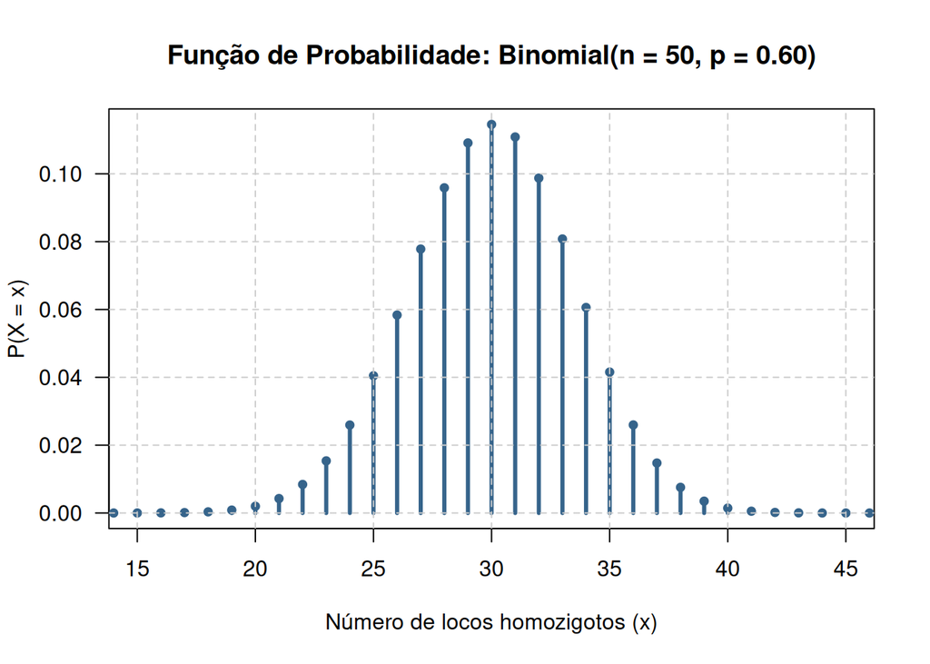

Função de probabilidade da distribuição Binomial(50, 0.60).

```r
# Parâmetros
n_par <- 50
p_par <- 0.6
x_grid <- 0:n_par
prob_grid <- dbinom(x_grid, size = n_par, prob = p_par)

# Gráfico de barras da função de probabilidade
plot(x_grid, prob_grid, type = "h", lwd = 3, col = "steelblue4", main = "Função de Probabilidade: Binomial(n = 50, p = 0.60)",
    xlab = "Número de locos homozigotos (x)", ylab = "P(X = x)", xlim = c(15, 45),
    las = 1)
points(x_grid, prob_grid, pch = 19, col = "steelblue4", cex = 0.8)
grid(nx = NULL, ny = NULL, lty = 2, col = "gray80")
```

Podem ser observadas as seguintes características:

- Unimodalidade: A massa de probabilidade concentra-se em torno do ponto central $x = 30$, decaindo simetricamente para ambas as extremidades.
- Cauda curta em extremos: A probabilidade de obter menos de $15$ ou mais de $45$ locos homozigotos é praticamente nula ($< 10^{-5}$).

### Resposta 15h

A Função de Distribuição Acumulada (F(x)) é dada pelo somatório cumulativo das probabilidades pontuais até o valor $x$:

$$F(x) = P(X \le x) = \begin{cases}
0, & \text{se } x < 0 \\
\sum_{k=0}^{\lfloor x \rfloor} \binom{50}{k} (0{,}60)^k (0{,}40)^{50 - k}, & \text{se } 0 \le x < 50 \\
1, & \text{se } x \ge 50
\end{cases}$$

onde $\lfloor x \rfloor$ representa o maior inteiro menor ou igual a $x$.

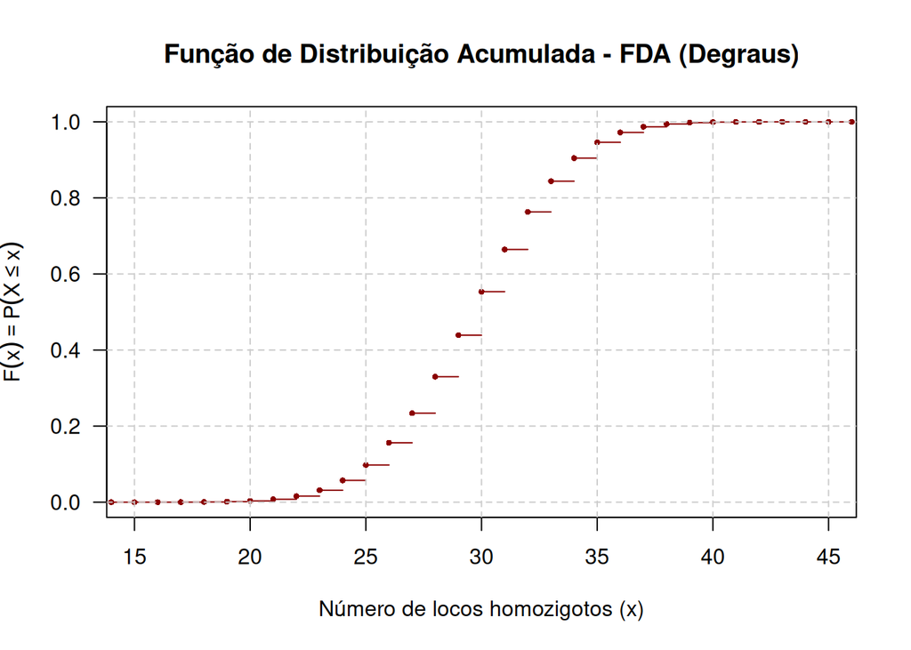

Função de Distribuição Acumulada em degraus da Binomial(50, 0.60).

```r
# Cálculo da FDA
fda_vals <- pbinom(x_grid, size = n_par, prob = p_par)

plot(stepfun(x_grid, c(0, fda_vals)), do.points = TRUE, pch = 16, cex = 0.6, col.points = "darkred",
    col.hor = "darkred", verticals = FALSE, main = "Função de Distribuição Acumulada - FDA (Degraus)",
    xlab = "Número de locos homozigotos (x)", ylab = expression(F(x) == P(X <= x)),
    xlim = c(15, 45), las = 1)
grid(nx = NULL, ny = NULL, lty = 2, col = "gray80")
```

### Resposta 15i

No contexto que escolhi, podemos definir os três eventos abaixo:

- Evento 1 (Homozigose muito baixa): probabilidade de um indivíduo apresentar no máximo $25$ locos homozigotos ($\le 50\%$ de homozigose no painel):

$$P(X \le 25) = F(25)$$

- Evento 2 (Faixa ideal de seleção):p robabilidade de o número de locos homozigotos estar estritamente contido no intervalo de $28$ a $35$ locos ($56\%$ a $70\%$ de homozigose):

$$P(28 \le X \le 35) = P(X \le 35) - P(X \le 27) = F(35) - F(27)$$

- Evento 3 (Homozigose extrema):Probabilidade de um indivíduo apresentar mais de $36$ locos homozigotos ($> 72\%$ de homozigose no genoma):

$$P(X > 36) = 1 - P(X \le 36) = 1 - F(36)$$

```r
# Cálculo exato das probabilidades via pbinom()
p_evento1 <- pbinom(25, size = n_par, prob = p_par)
p_evento2 <- pbinom(35, size = n_par, prob = p_par) - pbinom(27, size = n_par, prob = p_par)
p_evento3 <- 1 - pbinom(36, size = n_par, prob = p_par)

cat("P(X <= 25)           =", round(p_evento1, 4), paste0("(", round(p_evento1 *
    100, 2), "%)\n"))
P(X <= 25)           = 0.0978 (9.78%)
cat("P(28 <= X <= 35)     =", round(p_evento2, 4), paste0("(", round(p_evento2 *
    100, 2), "%)\n"))
P(28 <= X <= 35)     = 0.7121 (71.21%)
cat("P(X > 36)            =", round(p_evento3, 4), paste0("(", round(p_evento3 *
    100, 2), "%)\n"))
P(X > 36)            = 0.028 (2.8%)
```

### Resposta 15j

Para $X \sim \text{Binomial}(n = 50, \, p = 0{,}60)$:

- Esperança Matemática ($E(X)$): $E(X) = n p = 50 \times 0{,}60 = \mathbf{30{,}00}$
- Variância ($\text{Var}(X)$): $\text{Var}(X) = n p (1 - p) = 50 \times 0{,}60 \times 0{,}40 = \mathbf{12{,}00}$
- Desvio Padrão ($DP(X)$): $DP(X) = \sqrt{\text{Var}(X)} = \sqrt{12} \approx \mathbf{3{,}4641}$
- Moda ($\text{Moda}(X)$): calculada pelo piso de $(n + 1)p$: $\lfloor (50 + 1) \times 0{,}60 \rfloor = \lfloor 30{,}6 \rfloor = \mathbf{30}$.
- Mediana ($\text{Mediana}(X)$):Como $np = 30$ é um número inteiro, a mediana coincide com a média: $\mathbf{30}$.
- Coeficiente de Variação ($CV(X)$):$CV(X) = \frac{DP(X)}{E(X)} \times 100\% = \frac{3{,}4641}{30} \times 100\% \approx \mathbf{11{,}55\%}$

No caso, $E(X) = 30$ indica que, em média, espera-se que um indivíduo dessa população possua $30$ dos $50$ marcadores em estado de homozigose (uma taxa média de $60\%$).

Coeficiente de Variação ($CV = 11{,}55\%$): Indica baixa dispersão relativa em torno do número médio esperado de homozigotos.

### Resposta 15k

Para essa, vamos calcular os quantis primeiro.

```r
# | collapse: true | comment: ''

# Determinação dos quantis teóricos via qbinom()
ordens <- c(0.25, 0.5, 0.75, 0.95)
quantis_teoricos <- qbinom(ordens, size = n_par, prob = p_par)

names(quantis_teoricos) <- paste0("q_", ordens)
print(quantis_teoricos)
```

```
q_0.25  q_0.5 q_0.75 q_0.95
    28     30     32     36
```

- $q_{0{,}25} = \mathbf{28}$ locos
- $q_{0{,}50} = \mathbf{30}$ locos
- $q_{0{,}75} = \mathbf{32}$ locos
- $q_{0{,}95} = \mathbf{36}$ locos

A Mediana ($q_{0{,}50} = 30$) indica que $50\%$ dos indivíduos da população apresentam no máximo $30$ locos homozigotos no painel, os $50\%$ restantes apresentam $30$ ou mais locos. Já o $95º$ Percentil ($q_{0{,}95} = 36$) mostra que $95\%$ dos genótipos avaliados apresentam até $36$ locos homozigotos. Os depois 5% são os geneticamente mais endogâmicos da população.

### Resposta 15l

Vamos simular uma população de N = 1000 indivíduos genotipados para o painel de 50SNPs.

```r
# Fixa semente para reprodutibilidade estrita
set.seed(50)

# Tamanho amostral da simulação (1000 genótipos)
N_sim <- 1000

# Geração da amostra aleatória
amostra_sim <- rbinom(n = N_sim, size = n_par, prob = p_par)

# Visualização das 20 primeiras observações simuladas
head(amostra_sim, 20)
 [1] 28 31 33 27 30 36 28 29 36 34 31 32 29 35 32 28 27 31 35 33
```

### Resposta 15m

```r
# Estimativas amostrais
media_amostral <- mean(amostra_sim)
var_amostral <- var(amostra_sim)
dp_amostral <- sd(amostra_sim)

# Teóricos
media_teorica <- n_par * p_par
var_teorica <- n_par * p_par * (1 - p_par)
dp_teorico <- sqrt(var_teorica)

# Tabela de comparação
comparativo <- data.frame(Medida = c("Média / Esperança", "Variância", "Desvio Padrão"),
    `Valor Teórico` = c(media_teorica, var_teorica, dp_teorico), `Valor Simulado (N=1000)` = c(media_amostral,
        var_amostral, dp_amostral), `Erro Relativo (%)` = c(abs(media_amostral -
        media_teorica)/media_teorica * 100, abs(var_amostral - var_teorica)/var_teorica *
        100, abs(dp_amostral - dp_teorico)/dp_teorico * 100), check.names = FALSE)

knitr::kable(comparativo, digits = 4, align = "lccc")
```

| Medida | Valor Teórico | Valor Simulado (N=1000) | Erro Relativo (%) |
| --- | --- | --- | --- |
| Média / Esperança | 30.0000 | 30.1790 | 0.5967 |
| Variância | 12.0000 | 12.9159 | 7.6323 |
| Desvio Padrão | 3.4641 | 3.5939 | 3.7460 |

### Resposta 15n

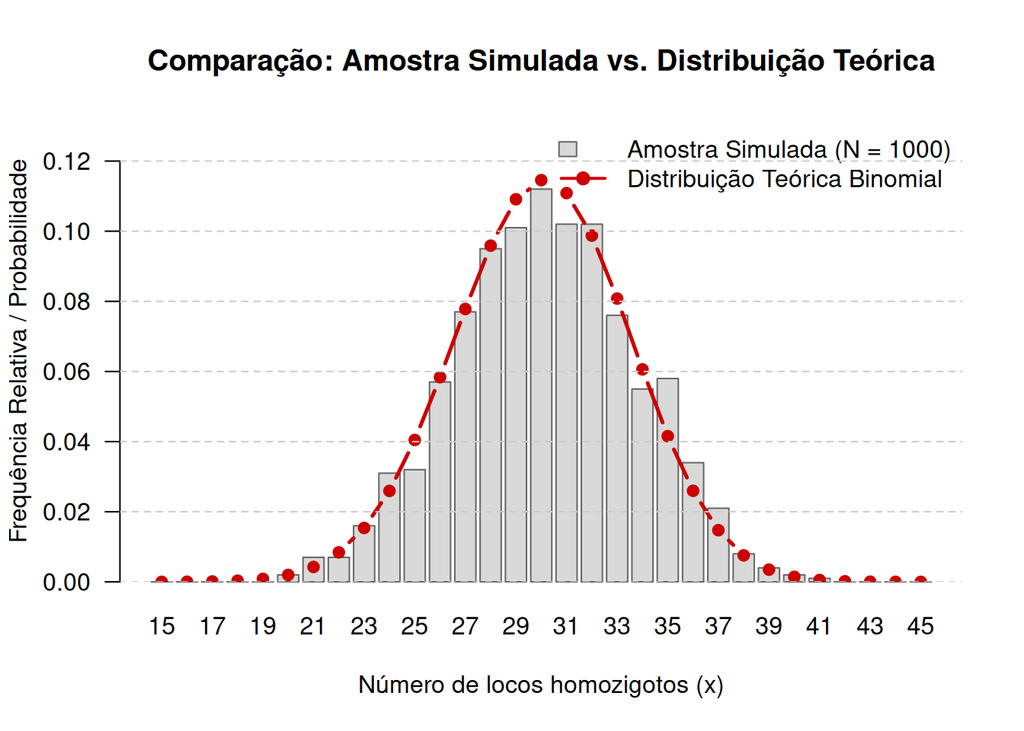

Frequências relativas empíricas da amostra simulada (barras) sobrepostas às probabilidades teóricas da Binomial (linha vermelha com pontos).

```r
# Frequências observadas na simulação
tab_obs <- table(factor(amostra_sim, levels = 15:45))/N_sim
eixo_x <- 15:45

# Gráfico de barras da amostra simulada
bp <- barplot(tab_obs, col = "gray85", border = "gray40", las = 1, main = "Comparação: Amostra Simulada vs. Distribuição Teórica",
    xlab = "Número de locos homozigotos (x)", ylab = "Frequência Relativa / Probabilidade",
    ylim = c(0, max(prob_grid) * 1.15))

# Curva teórica sobreposta
prob_teorica_alinhada <- dbinom(eixo_x, size = n_par, prob = p_par)
lines(bp, prob_teorica_alinhada, col = "red3", lwd = 2.5, type = "b", pch = 19, cex = 0.8)

legend("topright", legend = c("Amostra Simulada (N = 1000)", "Distribuição Teórica Binomial"),
    fill = c("gray85", NA), border = c("gray40", NA), lty = c(NA, 1), pch = c(NA,
        19), col = c(NA, "red3"), lwd = c(NA, 2), bty = "n")
grid(nx = NA, ny = NULL, lty = 2, col = "gray80")
```

O histograma de frequências relativas obtido a partir dos $1.000$ genótipos gerados fica bem próximo em forma quanto à linha vermelha da distribuição teórica. As barras exibem a assimetria praticamente nula e o pico modal coincide em $x = 30$, por exemplo.

### Resposta 15o

No exercício desenvolvido os parâmetros populacionais ($n = 50$ e $p = 0{,}60$) eram conhecidos, portanto simulamos os valores a partir de algo já definido. Na vida real isso dificilmente existirá portanto teriámos que estimá-lo. No exemplo que escolhi, teríamos que genotipar todos os indivíduos estudados e depois seguir a estimação do parâmetro, o que poderíamos fazer de duas maneiras:

- Pela estatística frequentista: nesse caso, o parâmetro em teoria é constante e seria estimado usando os métodos de acordo para estimá-lo.
- Pela estatística bayesiana: aqui, o parâmetro é tratado como variável, então usaríamos a distribuição a priori conjugada (omo $p \sim \text{Beta}(\alpha, \beta)$) e iríamos atualizar esse conhecimento através dos dados observados, gerando a posterior.

Teríamos, além disso, que testar para a independẽncia entre os marcadores.